# Ejercicios clasificación

Ignacio Vellido

11/18/2020

# Exercise 1: KNN

Create a function my_knn that accepts any measure from the philentropy package and performs basic knn. A possible function interface could be:

my_knn <- function(train, train_labels, test=NA, k=1, metric=“euclidean”)

The function will output the predictions over the test set (if given) or using the train set also as test set.

Select two distance/similarity measures and apply the my_knn function to each of them with different k choices for the breast cancer data and do a comparison of the results (try using a plot).

```r
wbcd <- read.csv("https://resources.oreilly.com/examples/9781784393908/raw/ac9fe41596dd42fc3877cfa8ed410dd346c43548/Machine%20Learning%20with%20R,%20Second%20Edition_Code/Chapter%2003/wisc_bc_data.csv")

wbcd %>% str()
```

```
'data.frame':   569 obs. of  32 variables:
 $ id               : int  87139402 8910251 905520 868871 9012568 906539 925291 87880 862989 89827 ...
 $ diagnosis        : chr  "B" "B" "B" "B" ...
 $ radius_mean      : num  12.3 10.6 11 11.3 15.2 ...
 $ texture_mean     : num  12.4 18.9 16.8 13.4 13.2 ...
 $ perimeter_mean   : num  78.8 69.3 70.9 73 97.7 ...
 $ area_mean        : num  464 346 373 385 712 ...
 $ smoothness_mean  : num  0.1028 0.0969 0.1077 0.1164 0.0796 ...
 $ compactness_mean : num  0.0698 0.1147 0.078 0.1136 0.0693 ...
 $ concavity_mean   : num  0.0399 0.0639 0.0305 0.0464 0.0339 ...
 $ points_mean      : num  0.037 0.0264 0.0248 0.048 0.0266 ...
 $ symmetry_mean    : num  0.196 0.192 0.171 0.177 0.172 ...
 $ dimension_mean   : num  0.0595 0.0649 0.0634 0.0607 0.0554 ...
 $ radius_se        : num  0.236 0.451 0.197 0.338 0.178 ...
 $ texture_se       : num  0.666 1.197 1.387 1.343 0.412 ...
```

[output cut: 18 more lines]

```r
wbcd <- na.omit(wbcd)
classes <- wbcd[, 2]
wbcd <- wbcd[, -(1:2)] %>% scale()
```

```r
philentropy::getDistMethods()
```

```
 [1] "euclidean"         "manhattan"         "minkowski"
 [4] "chebyshev"         "sorensen"          "gower"
 [7] "soergel"           "kulczynski_d"      "canberra"
[10] "lorentzian"        "intersection"      "non-intersection"
[13] "wavehedges"        "czekanowski"       "motyka"
[16] "kulczynski_s"      "tanimoto"          "ruzicka"
[19] "inner_product"     "harmonic_mean"     "cosine"
[22] "hassebrook"        "jaccard"           "dice"
[25] "fidelity"          "bhattacharyya"     "hellinger"
[28] "matusita"          "squared_chord"     "squared_euclidean"
[31] "pearson"           "neyman"            "squared_chi"
[34] "prob_symm"         "divergence"        "clark"
[37] "additive_symm"     "kullback-leibler"  "jeffreys"
[40] "k_divergence"      "topsoe"            "jensen-shannon"
[43] "jensen_difference" "taneja"            "kumar-johnson"
[46] "avg"
```

- NOTA: Los datos se deben estandarizar antes
- NOTA: La función de philentropy no permite suprimir los mensajes
- NOTA: El algoritmo es exageradamente lento, no usarlo con muchos datos de test

```r
# Mode function from Github
# En caso de empate, devuelve una cualquiera
Mode <- function(x) {
  ux <- unique(x)
  ux[which.max(tabulate(match(x, ux)))]
}

# The function will output the predictions over the test set (if given) or using the train set also as test set.
my_knn <- function(train, train_labels, test=NA, k=1, metric="euclidean") {

  # Aplica knn a una fila
  knn <- function(test, train, train_labels, k=1, metric="euclidean") {

    # Calcula distancia entre dos filas
    dist <- function(v1, v2, m="euclidean") {
      bind_rows(data.frame(t(v1)) , v2) %>%
        distance(method = m)
    }

    y <- train %>% apply(1, dist, v2=test, m=metric)

    # Ordenamos
    z <- y %>% sort() %>% head(k)

    # Cogemos los índices
    z <- z %>% names() %>% as.integer()

    # Cogemos la clase mayoritaria
    train_labels[z] %>% Mode()
  }

  x <- if (is.na(test)) train else test

  x %>% apply(1, knn, train, train_labels, k, metric)
}

train <- wbcd[-c(1,22,112,121,75),]
test <- wbcd[c(1,22,112,121,75),]

c1 <- my_knn(train, classes, test, 3, "euclidean")
c2 <- my_knn(train, classes, test, 3, "motyka")
c3 <- my_knn(train, classes, test, 3, "pearson")
cat("Euclidean: "); c1
cat("Motyka:    "); c2
cat("Pearson:   "); c3
```

```
Euclidean:   1  22 112 121  75
"B" "B" "B" "B" "B"
Motyka:      1  22 112 121  75
"M" "B" "B" "M" "M"
Pearson:     1  22 112 121  75
"M" "M" "M" "M" "B"
```

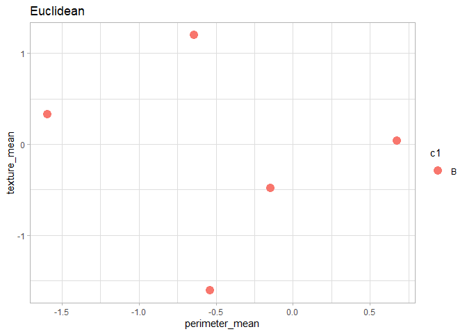

```r
test %>% as.data.frame() %>%
  ggplot(aes(x=perimeter_mean, y=texture_mean, color=c1)) +
    geom_point(size=4) +
    labs(title="Euclidean") +
    theme_light()
```

[figure not shown]

```r
test %>% as.data.frame() %>%
  ggplot(aes(x=perimeter_mean, y=texture_mean, color=c2)) +
    geom_point(size=4) +
    labs(title="Avg") +
    theme_light()
```

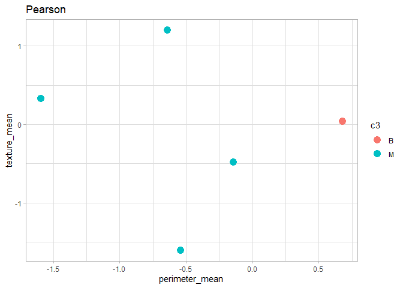

```r
test %>% as.data.frame() %>%
  ggplot(aes(x=perimeter_mean, y=texture_mean, color=c3)) +
    geom_point(size=4) +
    labs(title="Pearson") +
    theme_light()
```

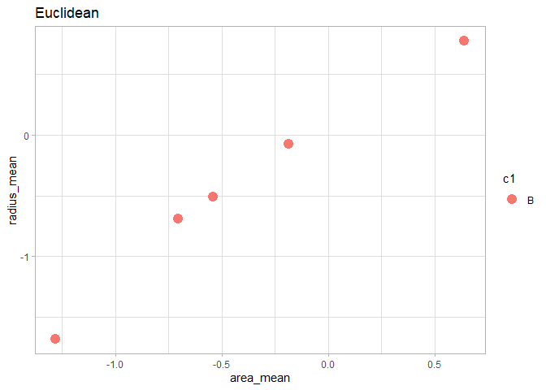

```r
test %>% as.data.frame() %>%
  ggplot(aes(x=area_mean, y=radius_mean, color=c1)) +
    geom_point(size=4) +
    labs(title="Euclidean") +
    theme_light()
```

[figure not shown]

```r
test %>% as.data.frame() %>%
  ggplot(aes(x=area_mean, y=radius_mean, color=c2)) +
    geom_point(size=4) +
    labs(title="Avg") +
    theme_light()
```

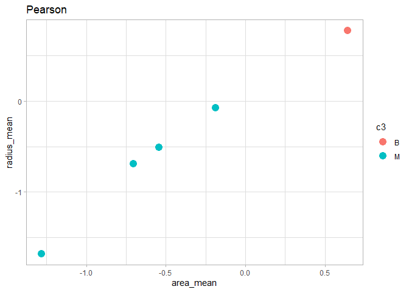

```r
test %>% as.data.frame() %>%
  ggplot(aes(x=area_mean, y=radius_mean, color=c3)) +
    geom_point(size=4) +
    labs(title="Pearson") +
    theme_light()
```

# Exercise 2: Logistic regression

Using the breast cancer dataset (all data, not only training) perform 10 fold-cv with logistic regression.

```r
wbcd <- read.csv("https://resources.oreilly.com/examples/9781784393908/raw/ac9fe41596dd42fc3877cfa8ed410dd346c43548/Machine%20Learning%20with%20R,%20Second%20Edition_Code/Chapter%2003/wisc_bc_data.csv")

wbcd <- na.omit(wbcd)
classes <- wbcd[, 2]

wbcd %>% head()
```

|  | id | diagnosis | radius_mean | texture_mean | perimeter_mean | area_mean | smoothness_mean | compactness_mean | concavity_mean | points_mean | symmetry_mean | dimension_mean | radius_se | texture_se | perimeter_se | area_se | smoothness_se | compactness_se | concavity_se | points_se | symmetry_se | dimension_se | radius_worst | texture_worst | perimeter_worst | area_worst | smoothness_worst | compactness_worst | concavity_worst | … |
| --- | --- | --- | --- | --- | --- | --- | --- | --- | --- | --- | --- | --- | --- | --- | --- | --- | --- | --- | --- | --- | --- | --- | --- | --- | --- | --- | --- | --- | --- | --- |
| 1 | 87139402 | B | 12.32 | 12.39 | 78.85 | 464.1 | 0.10280 | 0.06981 | 0.03987 | 0.03700 | 0.1959 | 0.05955 | 0.2360 | 0.6656 | 1.670 | 17.43 | 0.008045 | 0.011800 | 0.01683 | 0.012410 | 0.01924 | 0.002248 | 13.50 | 15.64 | 86.97 | 549.1 | 0.1385 | 0.1266 | 0.12420 | … |
| 2 | 8910251 | B | 10.60 | 18.95 | 69.28 | 346.4 | 0.09688 | 0.11470 | 0.06387 | 0.02642 | 0.1922 | 0.06491 | 0.4505 | 1.1970 | 3.430 | 27.10 | 0.007470 | 0.035810 | 0.03354 | 0.013650 | 0.03504 | 0.003318 | 11.88 | 22.94 | 78.28 | 424.8 | 0.1213 | 0.2515 | 0.19160 | … |
| 3 | 905520 | B | 11.04 | 16.83 | 70.92 | 373.2 | 0.10770 | 0.07804 | 0.03046 | 0.02480 | 0.1714 | 0.06340 | 0.1967 | 1.3870 | 1.342 | 13.54 | 0.005158 | 0.009355 | 0.01056 | 0.007483 | 0.01718 | 0.002198 | 12.41 | 26.44 | 79.93 | 471.4 | 0.1369 | 0.1482 | 0.10670 | … |
| 4 | 868871 | B | 11.28 | 13.39 | 73.00 | 384.8 | 0.11640 | 0.11360 | 0.04635 | 0.04796 | 0.1771 | 0.06072 | 0.3384 | 1.3430 | 1.851 | 26.33 | 0.011270 | 0.034980 | 0.02187 | 0.019650 | 0.01580 | 0.003442 | 11.92 | 15.77 | 76.53 | 434.0 | 0.1367 | 0.1822 | 0.08669 | … |
| 5 | 9012568 | B | 15.19 | 13.21 | 97.65 | 711.8 | 0.07963 | 0.06934 | 0.03393 | 0.02657 | 0.1721 | 0.05544 | 0.1783 | 0.4125 | 1.338 | 17.72 | 0.005012 | 0.014850 | 0.01551 | 0.009155 | 0.01647 | 0.001767 | 16.20 | 15.73 | 104.50 | 819.1 | 0.1126 | 0.1737 | 0.13620 | … |
| 6 | 906539 | B | 11.57 | 19.04 | 74.20 | 409.7 | 0.08546 | 0.07722 | 0.05485 | 0.01428 | 0.2031 | 0.06267 | 0.2864 | 1.4400 | 2.206 | 20.30 | 0.007278 | 0.020470 | 0.04447 | 0.008799 | 0.01868 | 0.003339 | 13.07 | 26.98 | 86.43 | 520.5 | 0.1249 | 0.1937 | 0.25600 | … |

```r
train <- wbcd[-c(1,22,112,121,75),]
classes <- classes[-c(1,22,112,121,75)]
test <- wbcd[c(1,22,112,121,75),]

test %>% head()
```

|  | id | diagnosis | radius_mean | texture_mean | perimeter_mean | area_mean | smoothness_mean | compactness_mean | concavity_mean | points_mean | symmetry_mean | dimension_mean | radius_se | texture_se | perimeter_se | area_se | smoothness_se | compactness_se | concavity_se | points_se | symmetry_se | dimension_se | radius_worst | texture_worst | perimeter_worst | area_worst | smoothness_worst | compactness_worst | concavity_worst | … |
| --- | --- | --- | --- | --- | --- | --- | --- | --- | --- | --- | --- | --- | --- | --- | --- | --- | --- | --- | --- | --- | --- | --- | --- | --- | --- | --- | --- | --- | --- | --- |
| 1 | 87139402 | B | 12.320 | 12.39 | 78.85 | 464.1 | 0.10280 | 0.06981 | 0.03987 | 0.03700 | 0.1959 | 0.05955 | 0.2360 | 0.6656 | 1.670 | 17.43 | 0.008045 | 0.011800 | 0.016830 | 0.012410 | 0.01924 | 0.002248 | 13.500 | 15.64 | 86.97 | 549.1 | 0.13850 | 0.1266 | 0.12420 | … |
| 22 | 919812 | B | 11.690 | 24.44 | 76.37 | 406.4 | 0.12360 | 0.15520 | 0.04515 | 0.04531 | 0.2131 | 0.07405 | 0.2957 | 1.9780 | 2.158 | 20.95 | 0.012880 | 0.034950 | 0.018650 | 0.017660 | 0.01560 | 0.005824 | 12.980 | 32.19 | 86.12 | 487.7 | 0.17680 | 0.3251 | 0.13950 | … |
| 112 | 871001502 | B | 8.219 | 20.70 | 53.27 | 203.9 | 0.09405 | 0.13050 | 0.13210 | 0.02168 | 0.2222 | 0.08261 | 0.1935 | 1.9620 | 1.243 | 10.21 | 0.012430 | 0.054160 | 0.077530 | 0.010220 | 0.02309 | 0.011780 | 9.092 | 29.72 | 58.08 | 249.8 | 0.16300 | 0.4310 | 0.53810 | … |
| 121 | 86561 | B | 13.850 | 17.21 | 88.44 | 588.7 | 0.08785 | 0.06136 | 0.01420 | 0.01141 | 0.1614 | 0.05890 | 0.2185 | 0.8561 | 1.495 | 17.91 | 0.004599 | 0.009169 | 0.009127 | 0.004814 | 0.01247 | 0.001708 | 15.490 | 23.58 | 100.30 | 725.9 | 0.11570 | 0.1350 | 0.08115 | … |
| 75 | 8711216 | B | 16.840 | 19.46 | 108.40 | 880.2 | 0.07445 | 0.07223 | 0.05150 | 0.02771 | 0.1844 | 0.05268 | 0.4789 | 2.0600 | 3.479 | 46.61 | 0.003443 | 0.026610 | 0.030560 | 0.011100 | 0.01520 | 0.001519 | 18.220 | 28.07 | 120.30 | 1032.0 | 0.08774 | 0.1710 | 0.18820 | … |

```r
glmFit <- train(train[,-2], y = train[,2],
                method = "glm",
                preProcess = c("center", "scale"),
                tuneLength = 10, control=glm.control(maxit=500),
                trControl = trainControl(method = "cv"))
glmFit
```

```
Generalized Linear Model

564 samples
 31 predictor
  2 classes: 'B', 'M'

Pre-processing: centered (31), scaled (31)
Resampling: Cross-Validated (10 fold)
Summary of sample sizes: 508, 508, 508, 508, 508, 508, ...
Resampling results:

  Accuracy   Kappa
  0.9451074  0.8843792
```

```r
glm.probs <- predict(glmFit, newdata=test[,-2], type="prob")
glm.pred <- ifelse(glm.probs > 0.5,"B","M")

print("Probabilities: ")
glm.probs %>% as.matrix()
```

```
[1] "Probabilities: "
               B            M
1   1.000000e+00 2.220446e-16
22  1.000000e+00 2.220446e-16
112 1.000000e+00 2.220446e-16
121 1.000000e+00 2.220446e-16
75  2.220446e-16 1.000000e+00
```

# Exercise 3: LDA/QDA

## 1

- Try lda with all Lag variables.

```r
Smarket %>% str()
```

```
'data.frame':   1250 obs. of  9 variables:
 $ Year     : num  2001 2001 2001 2001 2001 ...
 $ Lag1     : num  0.381 0.959 1.032 -0.623 0.614 ...
 $ Lag2     : num  -0.192 0.381 0.959 1.032 -0.623 ...
 $ Lag3     : num  -2.624 -0.192 0.381 0.959 1.032 ...
 $ Lag4     : num  -1.055 -2.624 -0.192 0.381 0.959 ...
 $ Lag5     : num  5.01 -1.055 -2.624 -0.192 0.381 ...
 $ Volume   : num  1.19 1.3 1.41 1.28 1.21 ...
 $ Today    : num  0.959 1.032 -0.623 0.614 0.213 ...
 $ Direction: Factor w/ 2 levels "Down","Up": 2 2 1 2 2 2 1 2 2 2 ...
```

Hacemos test de normalidad con Shapiro-test:

```r
normality(Smarket) %>% filter(p_value < 0.05)
```

| vars | statistic | p_value | sample |
| --- | --- | --- | --- |
| Year | 0.8889958 | 4.785873e-29 | 1250 |
| Lag1 | 0.9721873 | 8.888786e-15 | 1250 |
| Lag2 | 0.9721727 | 8.798395e-15 | 1250 |
| Lag3 | 0.9724040 | 1.034889e-14 | 1250 |
| Lag4 | 0.9724226 | 1.048548e-14 | 1250 |
| Lag5 | 0.9701079 | 2.148901e-15 | 1250 |
| Volume | 0.9535177 | 1.792894e-19 | 1250 |
| Today | 0.9722298 | 9.156928e-15 | 1250 |

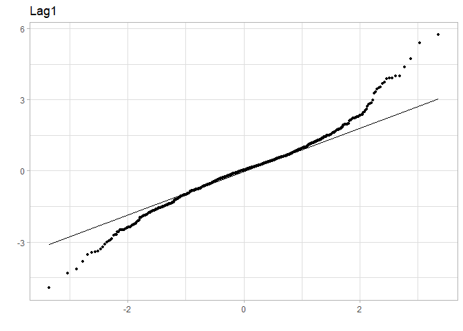

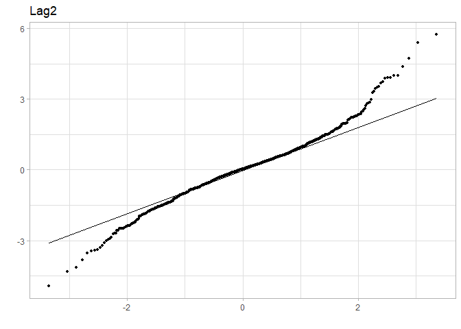

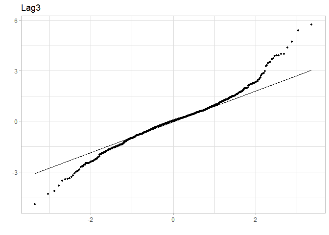

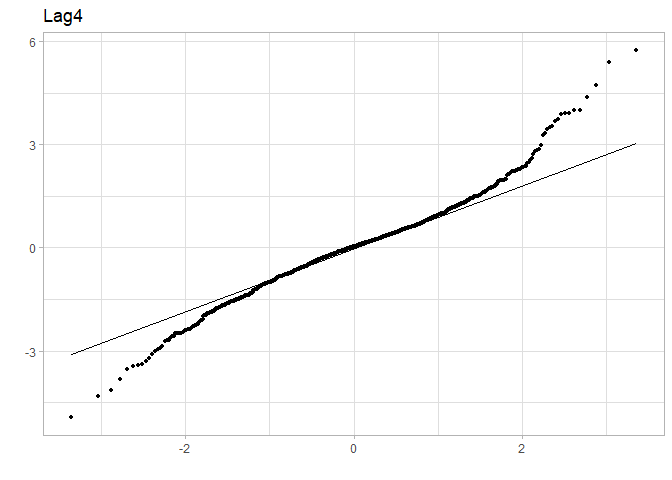

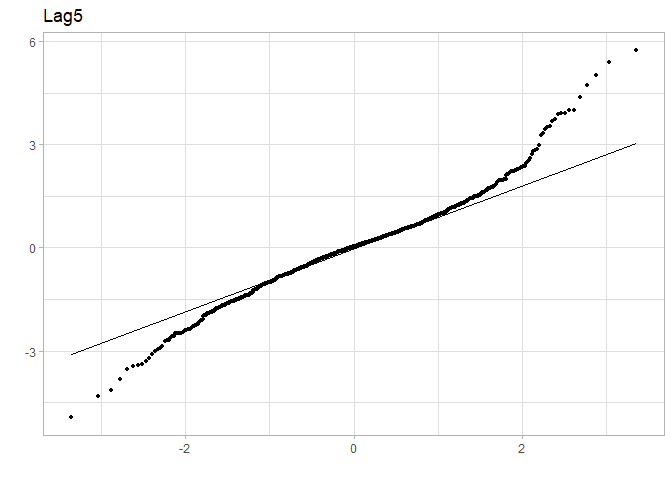

```r
names <- names(Smarket)
bins <- c(10,10,15,15,14,18)
plt <- list(length = length(names))

x<-rnorm(100, mean=0, sd=1)

for (i in 2:6) {
  ggplot(Smarket, aes_string(sample=names[i])) +
    stat_qq(size=1) +
    stat_qq_line() +
    labs(title="", x="", y="") +
    theme_light() -> plt[[i]]

  print(plt[[i]] + labs(title=sprintf("%s", names[i]), x=""))
}
```

No se cumplen los requisitos de LDA para las variables Lag. Lo hacemos de todas maneras:

```r
train <- Smarket %>% dplyr::select(Lag1, Lag2, Lag3, Lag4, Lag5)
classes <- Smarket %>% dplyr::select(Direction) %>% unlist()
```

```r
ldaFit <- train(train, classes,
                method = "lda",
                preProcess = c("center", "scale"),
                tuneLength = 10,
                trControl = trainControl(method = "cv"))

ldaFit
ldaFit$finalModel
confusionMatrix(ldaFit)
```

```
Linear Discriminant Analysis

1250 samples
   5 predictor
   2 classes: 'Down', 'Up'

Pre-processing: centered (5), scaled (5)
Resampling: Cross-Validated (10 fold)
Summary of sample sizes: 1124, 1125, 1125, 1125, 1126, 1124, ...
Resampling results:

  Accuracy   Kappa
  0.4959419  -0.03090072

Call:
lda(x, y)

Prior probabilities of groups:
  Down     Up
0.4816 0.5184

Group means:
            Lag1        Lag2         Lag3         Lag4         Lag5
Down  0.04123180  0.02497460 -0.006358916 -0.004371538 -0.005623679
Up   -0.03830485 -0.02320171  0.005907512  0.004061213  0.005224467

Coefficients of linear discriminants:
             LD1
Lag1 -0.84459978
Lag2 -0.52255254
Lag3  0.10995864
Lag4  0.08577751
Lag5  0.11134488
Cross-Validated (10 fold) Confusion Matrix

(entries are percentual average cell counts across resamples)

          Reference
Prediction Down   Up
      Down  8.8 11.0
      Up   39.4 40.8

 Accuracy (average) : 0.496
```

Obtenemos resultados muy malos.

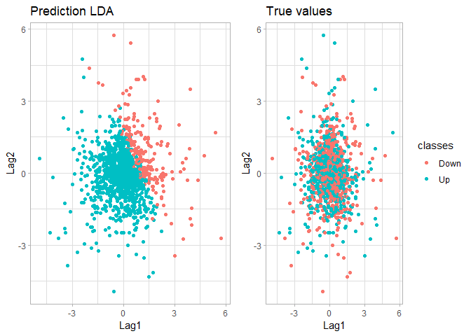

```r
ggplot(train, aes(x = Lag1, y = Lag2, color=predict(ldaFit))) +
  geom_point(show.legend = F) +
  labs(title="Prediction LDA") +
  theme_light() -> ldaplot

ggplot(train, aes(x = Lag1, y = Lag2, color=classes)) +
  geom_point() +
  labs(title="True values") +
  theme_light() -> trueplot

plot_grid(plotlist=list(ldaplot,trueplot), ncol=2, label_size = 1)
```

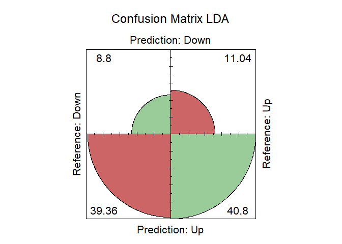

```r
ctable <- confusionMatrix(ldaFit)$table
fourfoldplot(ctable, color = c("#99CC99", "#CC6666"), std = "all.max",
             conf.level = 0, margin = 1, main = "Confusion Matrix LDA")
```

- Make a quick comparison between logistic regression and lda.

```r
glmFit <- train(train, classes,
                method = "glm",
                preProcess = c("center", "scale"),
                tuneLength = 10,
                control=glm.control(maxit=1500),
                trControl = trainControl(method = "cv"))

glmFit
confusionMatrix(glmFit)
```

```
Generalized Linear Model

1250 samples
   5 predictor
   2 classes: 'Down', 'Up'

Pre-processing: centered (5), scaled (5)
Resampling: Cross-Validated (10 fold)
Summary of sample sizes: 1124, 1125, 1126, 1125, 1125, 1126, ...
Resampling results:

  Accuracy   Kappa
  0.5175751  0.01185731

Cross-Validated (10 fold) Confusion Matrix

(entries are percentual average cell counts across resamples)

          Reference
Prediction Down   Up
      Down  8.8  8.9
      Up   39.4 43.0

 Accuracy (average) : 0.5176
```

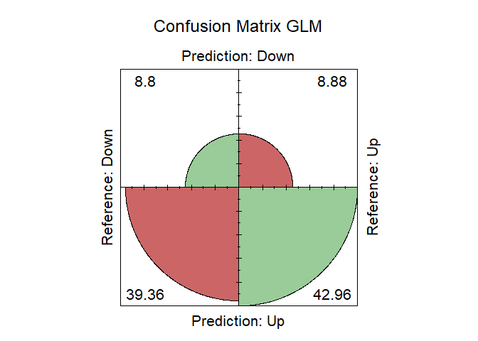

```r
ctable <- confusionMatrix(glmFit)$table
fourfoldplot(ctable, color = c("#CC6666","#99CC99"), std = "all.max",
             conf.level = 0, margin = 1, main = "Confusion Matrix GLM")
```

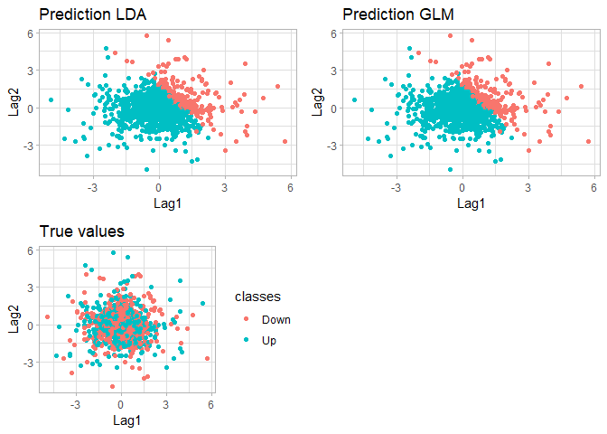

```r
ggplot(train, aes(x = Lag1, y = Lag2, color=predict(glmFit))) +
  geom_point(show.legend = F) +
  labs(title="Prediction GLM") +
  theme_light() -> glmplot

plot_grid(plotlist=list(ldaplot,glmplot,trueplot), ncol=2, label_size = 1)
```

- Try with qda and compare all three methods. Plot the results.

```r
qdaFit <- train(train, classes,
                method = "qda",
                preProcess = c("center", "scale"),
                tuneLength = 10,
                trControl = trainControl(method = "cv"))

qdaFit
qdaFit$finalModel

confusionMatrix(qdaFit)
```

```
Quadratic Discriminant Analysis

1250 samples
   5 predictor
   2 classes: 'Down', 'Up'

Pre-processing: centered (5), scaled (5)
Resampling: Cross-Validated (10 fold)
Summary of sample sizes: 1125, 1125, 1126, 1124, 1124, 1125, ...
Resampling results:

  Accuracy   Kappa
  0.5095674  0.002203797

Call:
qda(x, y)

Prior probabilities of groups:
  Down     Up
0.4816 0.5184

Group means:
            Lag1        Lag2         Lag3         Lag4         Lag5
Down  0.04123180  0.02497460 -0.006358916 -0.004371538 -0.005623679
Up   -0.03830485 -0.02320171  0.005907512  0.004061213  0.005224467
Cross-Validated (10 fold) Confusion Matrix

(entries are percentual average cell counts across resamples)

          Reference
Prediction Down   Up
      Down 13.0 13.8
      Up   35.2 38.0

 Accuracy (average) : 0.5096
```

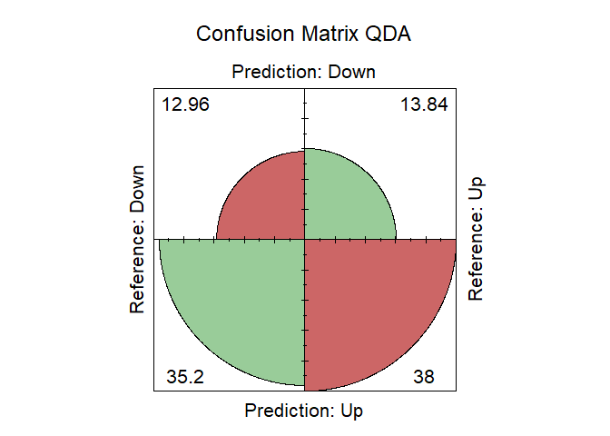

```r
ctable <- confusionMatrix(qdaFit)$table
fourfoldplot(ctable, color = c("#99CC99", "#CC6666"), std = "all.max",
             conf.level = 0, margin = 1, main = "Confusion Matrix QDA")
```

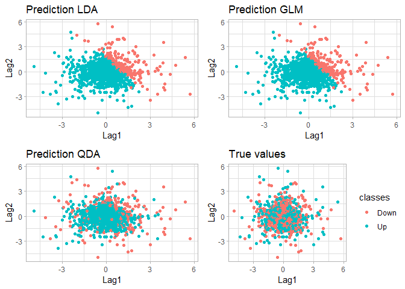

```r
ggplot(train, aes(x = Lag1, y = Lag2, color=predict(qdaFit))) +
  geom_point(show.legend = F) +
  labs(title="Prediction QDA") +
  theme_light() -> qdaplot

plot_grid(plotlist=list(ldaplot,glmplot,qdaplot,trueplot), ncol=2, label_size = 1)
```

## 2

Using only the information in file clasif_train_alumnos.csv:

```r
results <- read_csv("E:/Nacho/Desktop/GitHub/DATCOM/IntDat/Clasificacion/clasif_train_alumnos.csv")
results
```

| X1 | out_train_knn | out_train_lda | out_train_qda |
| --- | --- | --- | --- |
| appendicitis | 0.8834602 | 0.8815461 | 0.8690241 |
| australian | 0.7277419 | 0.8605475 | 0.8072464 |
| balance | 0.9072122 | 0.8791122 | 0.9167999 |
| bupa | 0.7405521 | 0.7024224 | 0.6447628 |
| contraceptive | 0.6168944 | 0.5236485 | 0.5314180 |
| haberman | 0.7795116 | 0.7519934 | 0.7567115 |
| hayes-roth | 0.6475524 | 0.5604167 | 0.7361111 |
| heart | 0.7342975 | 0.8576132 | 0.8777778 |
| iris | 0.9791045 | 0.9800000 | 0.9814815 |
| led7digit | 0.7636971 | 0.7635556 | 0.7680556 |

[output cut: 10 more lines]

- Compare lda and qda using Wilcoxon.

TABLA NORMALIZADA - lda (other) vs qda (ref) para WILCOXON + 0.1 porque wilcox R falla para valores == 0 en la tabla

```r
difs <- (results[,3] - results[,4]) / results[,3]
difs <- difs %>% as.matrix()
res_norm <- cbind(ifelse (difs<0, abs(difs)+0.1, 0+0.1), ifelse (difs>0,    abs(difs)+0.1, 0+0.1))
colnames(res_norm) <- c(colnames(results)[3], colnames(results)[4])
```

```r
# Aplicación del test de WILCOXON
wilcoxon <- wilcox.test(res_norm[,1], res_norm[,2], alternative = "two.sided", paired=TRUE)
Rmas <- wilcoxon$statistic

pvalue <- wilcoxon$p.value

wilcoxon <- wilcox.test(res_norm[,2], res_norm[,1], alternative = "two.sided", paired=TRUE)
Rmenos <- wilcoxon$statistic

wilcoxon
cat("R+: ")
Rmas
cat("R-: ")
Rmenos
cat("p-value: ")
pvalue
```

```
    Wilcoxon signed rank exact test

data:  res_norm[, 2] and res_norm[, 1]
V = 66, p-value = 0.1536
alternative hypothesis: true location shift is not equal to 0

R+:   V
144
R-:  V
66
p-value: [1] 0.1536465
```

- Perform a multiple comparison using Friedman.

```r
# Aplicación del test de Friedman
test_friedman <- friedman.test(as.matrix(results[,2:4]))
test_friedman
```

```
    Friedman rank sum test

data:  as.matrix(results[, 2:4])
Friedman chi-squared = 1.3, df = 2, p-value = 0.522
```

El p-value es >0.05 por lo que no podemos concluir que haya al menos un par de algoritmos de calidad diferente.

- Using Holm see if there is a winning algorithm (even if Friedman says there is no chance…).

```r
# Aplicación del test post-hoc de HOLM
tam <- dim(results[,2:4])
groups <- rep(1:tam[2], each=tam[1])

cat("1 = KNN, 2 = LDA, 3 = QDA")
pairwise.wilcox.test(as.matrix(results[,2:4]), groups, p.adjust = "holm", paired = TRUE)
```

```
1 = KNN, 2 = LDA, 3 = QDA
    Pairwise comparisons using Wilcoxon signed rank exact test

data:  as.matrix(results[, 2:4]) and groups

  1    2
2 0.65 -
3 0.59 0.53

P value adjustment method: holm
```

Todos los p-values son mayores que 0.05 por lo que tal y como nos había dicho el test de Friedman no podemos asegurar para ningún par de test que sean de calidad diferente.